# Xenium BC data analysis

Xiao Zhang

2025-04-01

This vignette introduces the CAESAR.Suite workflow for the analysis of Xenium BC spatial transcriptomics dataset. In this vignette, the workflow of CAESAR.Suite consists of five steps

- Reference dataset and target dataset preprocessing
- Detect signature genes as cell type markers from scRNA-seq reference datasets
- Annotate Xenium BC data using CAESAR
- Enrichment analysis for Xenium BC data using CAESAR
- Downstream analysis (i.e. , signature gene analysis, visualization of cell types and coembeddings)

## Load and quality control both reference and target data

```r
set.seed(1) # set a random seed for reproducibility.
library(CAESAR.Suite) # load the package of CAESAR.Suite method
library(Seurat)
library(ProFAST)
library(ggplot2)
library(msigdbr)
library(dplyr)
```

Those data can be downloaded and load to the current working path by the following command:

```r
githubURL <- "https://github.com/XiaoZhangryy/CAESAR.Suite/blob/master/vignettes_data/BC_scRNAList.rda?raw=true"
BC_scRNAList_file <- file.path(tempdir(), "BC_scRNAList.rda")
download.file(githubURL, BC_scRNAList_file, mode='wb')
load(BC_scRNAList_file)

print(BC_scRNAList)
```

```
#> $Ref1
#> An object of class Seurat
#> 302 features across 7023 samples within 1 assay
#> Active assay: RNA (302 features, 0 variable features)
#>  2 layers present: counts, data
#>
#> $Ref2
#> An object of class Seurat
#> 302 features across 8609 samples within 1 assay
#> Active assay: RNA (302 features, 0 variable features)
#>  2 layers present: counts, data
```

```r
githubURL <- "https://github.com/XiaoZhangryy/CAESAR.Suite/blob/master/vignettes_data/BC_XeniumList.rda?raw=true"
BC_XeniumList_file <- file.path(tempdir(), "BC_XeniumList.rda")
download.file(githubURL, BC_XeniumList_file, mode='wb')
load(BC_XeniumList_file)

print(BC_XeniumList)
```

```
#> $BC1
#> An object of class Seurat
#> 302 features across 3000 samples within 1 assay
#> Active assay: RNA (302 features, 0 variable features)
#>  2 layers present: counts, data
#>
#> $BC2
#> An object of class Seurat
#> 302 features across 3000 samples within 1 assay
#> Active assay: RNA (302 features, 0 variable features)
#>  2 layers present: counts, data
```

```r
githubURL <- "https://github.com/XiaoZhangryy/CAESAR.Suite/blob/master/vignettes_data/BC_feature_imgList.rda?raw=true"
BC_feature_imgList_file <- file.path(tempdir(), "BC_feature_imgList.rda")
download.file(githubURL, BC_feature_imgList_file, mode='wb')
load(BC_feature_imgList_file)

print(sapply(BC_feature_imgList, dim))
```

```
#>       BC1  BC2
#> [1,] 3000 3000
#> [2,]  576  576
```

Users can perform appropriate quality control on the reference dataset and target datasets. Genes expressed in less than one cell are required to remove to avoid unknown errors. Other quality control steps can be set by the user according to the data quality. Here, since scRNA-seq reference datasets and Xenium target datasets had been aligned, we do not perform quality control.

```r
# BC_scRNAList <- lapply(BC_scRNAList,  function(seu) {
#     CreateSeuratObject(
#         counts = seu@assays$RNA@counts,
#         meta.data = seu@meta.data,
#         min.features = 5,
#         min.cells = 1
#     )
# })
#
# print(BC_scRNAList)
#
#
# BC_XeniumList <- lapply(BC_XeniumList,  function(seu) {
#     CreateSeuratObject(
#         counts = seu@assays$RNA@counts,
#         meta.data = seu@meta.data,
#         min.features = 5,
#         min.cells = 1
#     )
# })
#
# print(BC_XeniumList)
#
# BC_feature_imgList <- lapply(1:2, function(i) {
#     BC_feature_imgList[[i]][colnames(BC_XeniumList[[i]]), ]
# })
```

## Preprocessing and align reference and target data

First, we normalize the data and select the variable genes. We align genes and variable genes of reference and target data.

```r
# align genes
common_genes <- Reduce(intersect, c(
    lapply(BC_scRNAList, rownames),
    lapply(BC_XeniumList, rownames)
))

print(length(common_genes))
```

```
#> [1] 302
```

```r
# all common genes are used as variable genes, as only around 300 genes here
BC_scRNAList <- lapply(BC_scRNAList, function(seu) {
    seu <- seu[common_genes, ]
    seu <- NormalizeData(seu)
    VariableFeatures(seu) <- common_genes
    seu
})

BC_XeniumList <- lapply(BC_XeniumList, function(seu) {
    seu <- seu[common_genes, ]
    seu <- NormalizeData(seu)
    VariableFeatures(seu) <- common_genes
    seu
})

print(BC_scRNAList)
```

```
#> $Ref1
#> An object of class Seurat
#> 302 features across 7023 samples within 1 assay
#> Active assay: RNA (302 features, 302 variable features)
#>  2 layers present: counts, data
#>
#> $Ref2
#> An object of class Seurat
#> 302 features across 8609 samples within 1 assay
#> Active assay: RNA (302 features, 302 variable features)
#>  2 layers present: counts, data
```

```r
print(BC_XeniumList)
```

```
#> $BC1
#> An object of class Seurat
#> 302 features across 3000 samples within 1 assay
#> Active assay: RNA (302 features, 302 variable features)
#>  2 layers present: counts, data
#>
#> $BC2
#> An object of class Seurat
#> 302 features across 3000 samples within 1 assay
#> Active assay: RNA (302 features, 302 variable features)
#>  2 layers present: counts, data
```

## Detect signature genes for each cell type using scRNA-seq reference data

We introduce how to use CAESAR to detect signature genes form scRNA-seq reference data. First, we calculate the co-embeddings.

```r
BC_scRNAList <- lapply(BC_scRNAList, ProFAST::NCFM, q = 50)
```

```
#> 2025-04-01 10:09:48.799768 : ***** Finish CoFAST, 0.033 mins elapsed.
#> 2025-04-01 10:09:51.336963 : ***** Finish CoFAST, 0.042 mins elapsed.
```

Then, we detect signature genes.

```r
# calculate cell-gene distance
BC_scRNAList <- lapply(BC_scRNAList, ProFAST::pdistance, reduction = "ncfm")
```

```
#> Calculate co-embedding distance...
#> Calculate co-embedding distance...
```

```r
# identify signature genes
sg_sc_List <- lapply(BC_scRNAList, function(seu) {
    print(table(seu$CellType))

    Idents(seu) <- seu$CellType
    find.sig.genes(seu)
})
```

```
#>
#>       Endothelial              CAFs               PVL           B-cells
#>                41               245                46                88
#>      Plasmablasts           T-cells           Myeloid Cancer Epithelial
#>              1453               902               206              4018
#> Normal Epithelial
#>                24
#>
#>       Endothelial              CAFs               PVL           B-cells
#>              2778              1292              1285                99
#>      Plasmablasts           T-cells           Myeloid Cancer Epithelial
#>                51               641               285               212
#> Normal Epithelial
#>              1966
```

```r
str(sg_sc_List)
```

```
#> List of 2
#>  $ Ref1:List of 9
#>   ..$ B-cells          :'data.frame':    302 obs. of  5 variables:
#>   .. ..$ distance        : num [1:302] 0.0645 0.0653 0.0657 0.0674 0.0676 ...
#>   .. ..$ expr.prop       : num [1:302] 0.591 0.295 0.148 0.182 0.443 ...
#>   .. ..$ expr.prop.others: num [1:302] 0.00216 0.00433 0.00173 0.01442 0.13771 ...
#>   .. ..$ label           : chr [1:302] "B-cells" "B-cells" "B-cells" "B-cells" ...
#>   .. ..$ gene            : chr [1:302] "MS4A1" "BANK1" "SPIB" "CCR7" ...
#>   ..$ CAFs             :'data.frame':    302 obs. of  5 variables:
#>   .. ..$ distance        : num [1:302] 0.0683 0.0684 0.0684 0.0684 0.0686 ...
#>   .. ..$ expr.prop       : num [1:302] 0.51 0.376 0.376 0.739 0.918 ...
#>   .. ..$ expr.prop.others: num [1:302] 0.00339 0.00162 0.00398 0.01107 0.01741 ...
#>   .. ..$ label           : chr [1:302] "CAFs" "CAFs" "CAFs" "CAFs" ...
#>   .. ..$ gene            : chr [1:302] "DPT" "PDGFRA" "GJB2" "POSTN" ...
#>   ..$ Cancer Epithelial:'data.frame':    302 obs. of  5 variables:
#>   .. ..$ distance        : num [1:302] 0.0881 0.0881 0.0881 0.0881 0.0882 ...
#>   .. ..$ expr.prop       : num [1:302] 0.892 0.967 0.922 0.82 0.824 ...
#>   .. ..$ expr.prop.others: num [1:302] 0.0729 0.1684 0.1135 0.0483 0.0622 ...
#>   .. ..$ label           : chr [1:302] "Cancer Epithelial" "Cancer Epithelial" "Cancer Epithelial" "Cancer Epithelial" ...
#>   .. ..$ gene            : chr [1:302] "KRT8" "KRT7" "CLDN4" "EPCAM" ...
#>   ..$ Endothelial      :'data.frame':    302 obs. of  5 variables:
#>   .. ..$ distance        : num [1:302] 0.0742 0.0743 0.0751 0.0755 0.0759 ...
#>   .. ..$ expr.prop       : num [1:302] 0.854 0.756 0.463 0.39 0.39 ...
#>   .. ..$ expr.prop.others: num [1:302] 0.000573 0.00043 0.000716 0 0.000859 ...
#>   .. ..$ label           : chr [1:302] "Endothelial" "Endothelial" "Endothelial" "Endothelial" ...
#>   .. ..$ gene            : chr [1:302] "CLEC14A" "VWF" "CLDN5" "SOX17" ...
#>   ..$ Myeloid          :'data.frame':    302 obs. of  5 variables:
#>   .. ..$ distance        : num [1:302] 0.0612 0.0616 0.0616 0.0616 0.0618 ...
#>   .. ..$ expr.prop       : num [1:302] 0.704 0.369 0.519 0.379 0.714 ...
#>   .. ..$ expr.prop.others: num [1:302] 0.003521 0.000293 0.0022 0.00176 0.006161 ...
#>   .. ..$ label           : chr [1:302] "Myeloid" "Myeloid" "Myeloid" "Myeloid" ...
#>   .. ..$ gene            : chr [1:302] "IGSF6" "CD163" "MNDA" "ITGAX" ...
#>   ..$ Normal Epithelial:'data.frame':    302 obs. of  5 variables:
#>   .. ..$ distance        : num [1:302] 0.0823 0.0842 0.0859 0.0864 0.0865 ...
#>   .. ..$ expr.prop       : num [1:302] 0.417 0.292 0.25 0.417 0.75 ...
#>   .. ..$ expr.prop.others: num [1:302] 0.00143 0.00286 0.00129 0.04958 0.49707 ...
#>   .. ..$ label           : chr [1:302] "Normal Epithelial" "Normal Epithelial" "Normal Epithelial" "Normal Epithelial" ...
#>   .. ..$ gene            : chr [1:302] "PIGR" "KIT" "KRT14" "KRT15" ...
#>   ..$ PVL              :'data.frame':    302 obs. of  5 variables:
#>   .. ..$ distance        : num [1:302] 0.0743 0.0744 0.0747 0.0752 0.0752 ...
```

[output cut: 56 more lines]

```
#>   .. ..$ expr.prop.others: num [1:302] 0.01338 0.05926 0.00614 0.11182 0.14104 ...
#>   .. ..$ label           : chr [1:302] "PVL" "PVL" "PVL" "PVL" ...
#>   .. ..$ gene            : chr [1:302] "AVPR1A" "NDUFA4L2" "FOXC2" "MYH11" ...
#>   ..$ Plasmablasts     :'data.frame':    302 obs. of  5 variables:
#>   .. ..$ distance        : num [1:302] 0.0581 0.0694 0.0723 0.0745 0.0791 ...
#>   .. ..$ expr.prop       : num [1:302] 0.745 0.922 1 0.706 0.922 ...
#>   .. ..$ expr.prop.others: num [1:302] 0.00105 0.01145 0.01542 0.00631 0.01718 ...
#>   .. ..$ label           : chr [1:302] "Plasmablasts" "Plasmablasts" "Plasmablasts" "Plasmablasts" ...
#>   .. ..$ gene            : chr [1:302] "TNFRSF17" "DERL3" "MZB1" "SLAMF7" ...
#>   ..$ T-cells          :'data.frame':    302 obs. of  5 variables:
#>   .. ..$ distance        : num [1:302] 0.0638 0.0639 0.0639 0.0642 0.0643 ...
#>   .. ..$ expr.prop       : num [1:302] 0.839 0.641 0.437 0.75 0.317 ...
#>   .. ..$ expr.prop.others: num [1:302] 0.00791 0.00289 0.00276 0.02246 0.00314 ...
#>   .. ..$ label           : chr [1:302] "T-cells" "T-cells" "T-cells" "T-cells" ...
#>   .. ..$ gene            : chr [1:302] "CD3E" "CD3D" "CD3G" "IL7R" ...
```

Finally, select marker genes for each cell type from the signature gene list.

```r
markerList <- lapply(sg_sc_List, marker.select, overlap.max = 1)

print(markerList)
```

```
#> $Ref1
#> $Ref1$`B-cells`
#> [1] "MS4A1" "BANK1" "SPIB"  "CCR7"
#>
#> $Ref1$CAFs
#> [1] "DPT"    "PDGFRA" "GJB2"   "POSTN"
#>
#> $Ref1$`Cancer Epithelial`
#> [1] "KRT8"  "KRT7"  "CLDN4" "EPCAM"
#>
#> $Ref1$Endothelial
#> [1] "CLEC14A" "VWF"     "CLDN5"   "SOX17"
#>
#> $Ref1$Myeloid
#> [1] "IGSF6" "CD163" "MNDA"  "ITGAX"
#>
#> $Ref1$`Normal Epithelial`
#> [1] "PIGR"  "KIT"   "KRT14" "KRT15"
#>
#> $Ref1$PVL
#> [1] "PDGFRB" "PTN"    "ACTA2"  "PCOLCE"
#>
#> $Ref1$Plasmablasts
#> [1] "CD79A"    "MZB1"     "DERL3"    "TNFRSF17"
#>
#> $Ref1$`T-cells`
#> [1] "CD3E"  "CD3D"  "CD247" "CD3G"
#>
#>
#> $Ref2
#> $Ref2$`B-cells`
#> [1] "CD19"  "TCL1A" "MS4A1" "BANK1"
#>
#> $Ref2$CAFs
#> [1] "DPT"   "FBLN1" "IGF1"  "LUM"
#>
#> $Ref2$`Cancer Epithelial`
#> [1] "SCGB2A1" "AGR3"    "ESR1"    "FOXA1"
#>
#> $Ref2$Endothelial
#> [1] "PECAM1"  "VWF"     "CLEC14A" "EGFL7"
#>
#> $Ref2$Myeloid
#> [1] "IGSF6" "LYZ"   "ITGAX" "AIF1"
#>
#> $Ref2$`Normal Epithelial`
#> [1] "KRT8"    "TACSTD2" "SDC4"    "DSP"
#>
#> $Ref2$PVL
#> [1] "AVPR1A"   "NDUFA4L2" "MYH11"    "PDGFRB"
#>
#> $Ref2$Plasmablasts
#> [1] "TNFRSF17" "DERL3"    "MZB1"     "SLAMF7"
#>
#> $Ref2$`T-cells`
#> [1] "CD3E" "CD3D" "CD3G" "IL7R"
```

Similarly, we first calculate co-embeddings for Xenium BC dataset. The difference is that spatial transcriptome data has spatial coordinates and image feature information, so we can obtain image-based spatial aware co-embeddings.

```r
BC_XeniumList <- lapply(1:2, function(i) {
    seu <- BC_XeniumList[[i]]

    # the spatial coordinates
    pos <- seu@meta.data[, c("x_centroid", "y_centroid")]
    print(head(pos))

    # the image feature
    feature_img <- BC_feature_imgList[[i]]

    seu <- CAESAR.coembedding.image(
        seu, feature_img, pos, reduction.name = "caesar", q = 50)
    seu
})
```

[output not shown]

[output cut: 413 more lines]

```
#> Update B
#> Update Lambda
#> Update Phi
#> iter = 30, elbo= -555124.780564, delbo=0.000282
#> 2025-04-01 10:10:25.724734 : ***** Finish calculate CAESAR embedding, 0.228 mins elapsed.
#> The spatial cooridnates are 2 dimensions
#> Find the adjacency matrix by bisection method...
#> Current radius is 200.5
#> Median of neighborhoods is 0
#> Current radius is 100.75
#> Median of neighborhoods is 65
#> Current radius is 50.88
#> Median of neighborhoods is 18
#> Current radius is 50.88
#> Median of neighborhoods is 5
```

```r
names(BC_XeniumList) <- paste0("BC", 1:2)

print(BC_XeniumList)
```

```
#> $BC1
#> An object of class Seurat
#> 302 features across 3000 samples within 1 assay
#> Active assay: RNA (302 features, 302 variable features)
#>  2 layers present: counts, data
#>  1 dimensional reduction calculated: caesar
#>
#> $BC2
#> An object of class Seurat
#> 302 features across 3000 samples within 1 assay
#> Active assay: RNA (302 features, 302 variable features)
#>  2 layers present: counts, data
#>  1 dimensional reduction calculated: caesar
```

Subsequently, the CAESAR co-embeddings and marker gene lists from scRNA-seq reference datasets are used to annotate the Xenium BC data.

```r
# convert marker list to marker frequency matrix
marker.freq <- markerList2mat(markerList)

# perform annotation using CAESAR and save results to Seurat object
BC_XeniumList <- lapply(
    BC_XeniumList, CAESAR.annotation, marker.freq = marker.freq,
    reduction.name = "caesar", add.to.meta = TRUE
)
```

```
#> Calculate co-embedding distance...
#> Calculate co-embedding distance...
```

```r
print(colnames(BC_XeniumList[[1]]@meta.data))
```

```
#>  [1] "orig.ident"             "nCount_RNA"             "nFeature_RNA"
#>  [4] "x_centroid"             "y_centroid"             "CAESAR"
#>  [7] "CAESARunasg"            "CAESARconf"             "dist_B.cells"
#> [10] "dist_CAFs"              "dist_Cancer.Epithelial" "dist_Endothelial"
#> [13] "dist_Myeloid"           "dist_Normal.Epithelial" "dist_PVL"
#> [16] "dist_Plasmablasts"      "dist_T.cells"           "prob_B.cells"
#> [19] "prob_CAFs"              "prob_Cancer.Epithelial" "prob_Endothelial"
#> [22] "prob_Myeloid"           "prob_Normal.Epithelial" "prob_PVL"
#> [25] "prob_Plasmablasts"      "prob_T.cells"
```

## Downstream analysis

In the following, we visualize the CAESAR annotation results.

```r
# set up colors
cols <- setNames(
    c(
        "#fdc086", "#386cb0", "#b30000", "#FBEA2E", "#731A73",
        "#FF8C00", "#F898CB", "#4DAF4A", "#a6cee3", "#737373"
    ),
    c(
        "B-cells", "CAFs", "Cancer Epithelial", "Endothelial", "Myeloid",
        "Normal Epithelial", "Plasmablasts", "PVL", "T-cells", "unassigned"
    )
)
celltypes <- c(
    "B-cells", "CAFs", "Cancer Epithelial", "Endothelial", "Myeloid",
    "Normal Epithelial", "Plasmablasts", "PVL", "T-cells", "unassigned"
)

BC_XeniumList <- lapply(BC_XeniumList, function(seu) {
    Idents(seu) <- factor(seu$CAESARunasg, levels = celltypes)

    pos <- seu@meta.data[, c("x_centroid", "y_centroid")]
    colnames(pos) <- paste0("pos", 1:2)
    seu@reductions[["pos"]] <- CreateDimReducObject(
        embeddings = as.matrix(pos),
        key = paste0("pos", "_"), assay = "RNA"
    )
    seu
})
```

First, we visualize the CAESAR annotation account for ‘unassigned’.

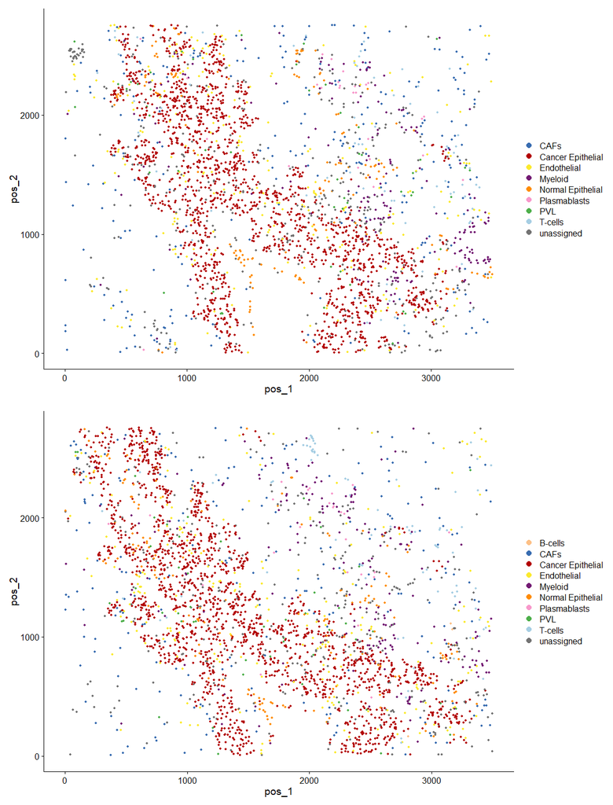

```r
plots <- lapply(BC_XeniumList, function(seu) {
    DimPlot(seu, reduction = "pos", cols = cols, pt.size = 1)
})

cowplot::plot_grid(plotlist = plots, ncol = 1)
```

The confidence level of the CAESAR annotation can be visualized by

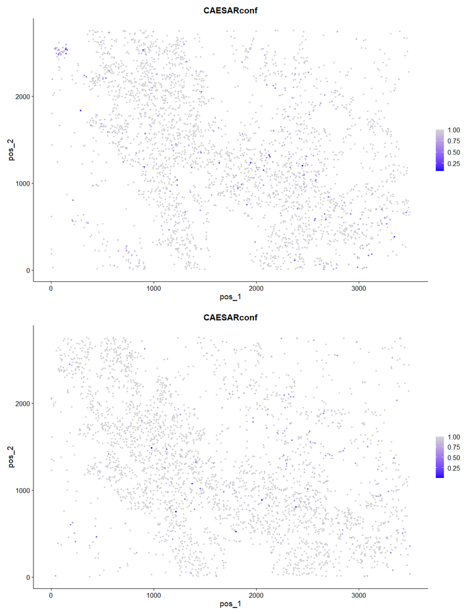

```r
plots <- lapply(BC_XeniumList, function(seu) {
    FeaturePlot(
        seu,
        reduction = "pos", features = "CAESARconf", pt.size = 1,
        cols = c("blue", "lightgrey"), min.cutoff = 0.0, max.cutoff = 1.0
    )
})

cowplot::plot_grid(plotlist = plots, ncol = 1)
```

Next, we detect and visualize the signature genes for each cell type.

```r
sg_List <- lapply(BC_XeniumList, find.sig.genes)

str(sg_List)
```

```
#> List of 2
#>  $ BC1:List of 9
#>   ..$ CAFs             :'data.frame':    302 obs. of  5 variables:
#>   .. ..$ distance        : num [1:302] 22.1 22.3 22.4 22.4 22.5 ...
#>   .. ..$ expr.prop       : num [1:302] 0.643 0.632 0.353 0.711 0.327 ...
#>   .. ..$ expr.prop.others: num [1:302] 0.0794 0.0951 0.056 0.1397 0.0435 ...
#>   .. ..$ label           : chr [1:302] "CAFs" "CAFs" "CAFs" "CAFs" ...
#>   .. ..$ gene            : chr [1:302] "FBLN1" "PTGDS" "DPT" "CCDC80" ...
#>   ..$ Cancer Epithelial:'data.frame':    302 obs. of  5 variables:
#>   .. ..$ distance        : num [1:302] 16.1 16.2 16.2 16.2 16.2 ...
#>   .. ..$ expr.prop       : num [1:302] 0.363 0.925 0.901 0.813 0.965 ...
#>   .. ..$ expr.prop.others: num [1:302] 0.0823 0.2794 0.2695 0.217 0.3738 ...
#>   .. ..$ label           : chr [1:302] "Cancer Epithelial" "Cancer Epithelial" "Cancer Epithelial" "Cancer Epithelial" ...
#>   .. ..$ gene            : chr [1:302] "LYPD3" "AGR3" "MLPH" "SCD" ...
#>   ..$ Endothelial      :'data.frame':    302 obs. of  5 variables:
#>   .. ..$ distance        : num [1:302] 22.8 22.9 23 23 23 ...
#>   .. ..$ expr.prop       : num [1:302] 0.461 0.768 0.289 0.338 0.268 ...
#>   .. ..$ expr.prop.others: num [1:302] 0.017 0.0451 0.0105 0.018 0.0177 ...
#>   .. ..$ label           : chr [1:302] "Endothelial" "Endothelial" "Endothelial" "Endothelial" ...
#>   .. ..$ gene            : chr [1:302] "HOXD9" "VWF" "EGFL7" "IL3RA" ...
#>   ..$ Myeloid          :'data.frame':    302 obs. of  5 variables:
#>   .. ..$ distance        : num [1:302] 27.5 27.5 27.6 28 28.1 ...
#>   .. ..$ expr.prop       : num [1:302] 0.64 0.609 0.594 0.426 0.888 ...
#>   .. ..$ expr.prop.others: num [1:302] 0.0239 0.0489 0.0474 0.0385 0.1327 ...
#>   .. ..$ label           : chr [1:302] "Myeloid" "Myeloid" "Myeloid" "Myeloid" ...
#>   .. ..$ gene            : chr [1:302] "ITGAX" "HAVCR2" "IGSF6" "CD86" ...
#>   ..$ Normal Epithelial:'data.frame':    302 obs. of  5 variables:
#>   .. ..$ distance        : num [1:302] 21.3 22.4 23.1 23.5 23.5 ...
#>   .. ..$ expr.prop       : num [1:302] 0.468 0.643 0.474 0.338 0.39 ...
#>   .. ..$ expr.prop.others: num [1:302] 0.0379 0.1167 0.0548 0.0611 0.1114 ...
#>   .. ..$ label           : chr [1:302] "Normal Epithelial" "Normal Epithelial" "Normal Epithelial" "Normal Epithelial" ...
#>   .. ..$ gene            : chr [1:302] "PIGR" "KRT15" "KIT" "KRT6B" ...
#>   ..$ PVL              :'data.frame':    302 obs. of  5 variables:
#>   .. ..$ distance        : num [1:302] 23.2 23.3 23.5 23.5 23.6 ...
#>   .. ..$ expr.prop       : num [1:302] 0.885 0.596 0.442 0.5 0.596 ...
#>   .. ..$ expr.prop.others: num [1:302] 0.196 0.185 0.117 0.166 0.223 ...
#>   .. ..$ label           : chr [1:302] "PVL" "PVL" "PVL" "PVL" ...
#>   .. ..$ gene            : chr [1:302] "PDGFRB" "ZEB1" "SFRP4" "EGFR" ...
#>   ..$ Plasmablasts     :'data.frame':    302 obs. of  5 variables:
#>   .. ..$ distance        : num [1:302] 29.1 29.7 30.7 31.3 32.3 ...
```

[output cut: 62 more lines]

```
#>   .. ..$ expr.prop.others: num [1:302] 0.00403 0.00403 0.00975 0.00605 0.03361 ...
#>   .. ..$ label           : chr [1:302] "Plasmablasts" "Plasmablasts" "Plasmablasts" "Plasmablasts" ...
#>   .. ..$ gene            : chr [1:302] "CD79A" "TNFRSF17" "MZB1" "DERL3" ...
#>   ..$ T-cells          :'data.frame':    302 obs. of  5 variables:
#>   .. ..$ distance        : num [1:302] 30.7 31 31 31.6 31.8 ...
#>   .. ..$ expr.prop       : num [1:302] 0.84 0.531 0.691 0.531 0.333 ...
#>   .. ..$ expr.prop.others: num [1:302] 0.024 0.0164 0.0319 0.0116 0.0134 ...
#>   .. ..$ label           : chr [1:302] "T-cells" "T-cells" "T-cells" "T-cells" ...
#>   .. ..$ gene            : chr [1:302] "CD3E" "CD3G" "IL7R" "CD3D" ...
#>   ..$ unassigned       :'data.frame':    302 obs. of  5 variables:
#>   .. ..$ distance        : num [1:302] 24.8 24.9 24.9 25 25 ...
#>   .. ..$ expr.prop       : num [1:302] 0.652 0.389 0.725 0.444 0.529 ...
#>   .. ..$ expr.prop.others: num [1:302] 0.361 0.144 0.558 0.144 0.381 ...
#>   .. ..$ label           : chr [1:302] "unassigned" "unassigned" "unassigned" "unassigned" ...
#>   .. ..$ gene            : chr [1:302] "MYLK" "MYH11" "ACTA2" "KRT5" ...
```

We remove unwanted variation by

```r
dist_names <- paste0("dist_", gsub("-|/| ", ".", setdiff(celltypes, "unassigned")))

distList <- lapply(BC_XeniumList, function(seu) {
    as.matrix(seu@meta.data[, dist_names])
})

seuInt <- CAESAR.RUV(BC_XeniumList, distList, verbose = FALSE, species = "human")

metaInt <- Reduce(rbind, lapply(BC_XeniumList, function(seu) {
    as.matrix(seu@meta.data[, "CAESARunasg", drop = FALSE])
})) %>% as.data.frame()
colnames(metaInt) <- "CAESARunasg"
row.names(metaInt) <- colnames(seuInt)
seuInt <- AddMetaData(seuInt, metaInt, col.name = colnames(metaInt))
Idents(seuInt) <- factor(seuInt$CAESARunasg, levels = names(cols))

print(seuInt)
```

```
#> An object of class Seurat
#> 302 features across 6000 samples within 1 assay
#> Active assay: CAESAR (302 features, 0 variable features)
#>  2 layers present: counts, data
```

Then, we can visualize the top three signature genes by a dot plot.

```r
# obtain the top three signature genes
celltypes_plot <- setdiff(celltypes, "unassigned")
top3sgs <- Intsg(sg_List, 3)[celltypes_plot]
print(top3sgs)
```

```
#> $`B-cells`
#> [1] "TCL1A"  "LILRA4" "SPIB"
#>
#> $CAFs
#> [1] "FBLN1"  "PTGDS"  "CCDC80"
#>
#> $`Cancer Epithelial`
#> [1] "AGR3"  "LYPD3" "MLPH"
#>
#> $Endothelial
#> [1] "HOXD9" "EGFL7" "VWF"
#>
#> $Myeloid
#> [1] "ITGAX"  "HAVCR2" "IGSF6"
#>
#> $`Normal Epithelial`
#> [1] "PIGR"  "KRT15" "KRT6B"
#>
#> $Plasmablasts
#> [1] "CD79A"    "TNFRSF17" "DERL3"
#>
#> $PVL
#> [1] "ZEB1"  "SFRP4" "CAV1"
#>
#> $`T-cells`
#> [1] "CD3G" "CD3E" "CD3D"
```

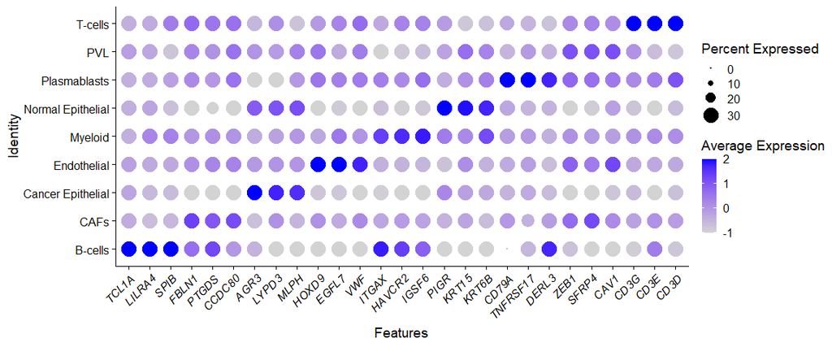

```r
sg_features <- unname(unlist(top3sgs))

DotPlot(
    seuInt,
    idents = celltypes_plot, col.min = -1, col.max = 2, dot.scale = 7,
    features = sg_features, scale.min = 0, scale.max = 30
) + theme(axis.text.x = element_text(face = "italic", angle = 45, vjust = 1, hjust = 1))
```

Next, we calculate the UMAP projections of co-embeddings of cells and the selected signature genes.

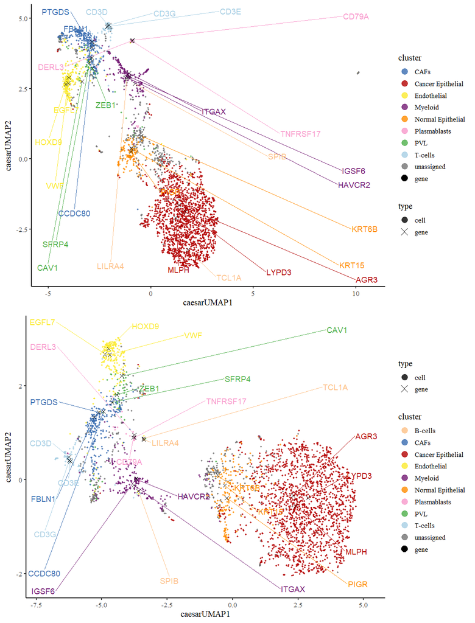

```r
# calculate coumap
BC_XeniumList <- lapply(
    BC_XeniumList, CoUMAP, reduction = "caesar",
    reduction.name = "caesarUMAP", gene.set = sg_features
)

df_gene_label <- data.frame(
    gene = unlist(top3sgs),
    label = rep(names(top3sgs), each = 3)
)

plots <- lapply(BC_XeniumList, function(seu) {
    CoUMAP.plot(
        seu, reduction = "caesarUMAP", gene_txtdata = df_gene_label,
        cols = c("gene" = "#000000", cols)
    )
})

cowplot::plot_grid(plotlist = plots, ncol = 1)
```

## Enrichment analysis

Next, we show how to use CAESAR for enrichment analysis. Here we choose GOBP pathways as an example. Let’s first get some pathways.

```r
# pathway_list <- msigdbr(species = "Homo sapiens", category = "C5", subcategory = "GO:BP") %>%
#     group_by(gs_name) %>%
#     summarise(genes = list(intersect(gene_symbol, common_genes))) %>%
#     tibble::deframe()
# n.pathway_list <- sapply(pathway_list, length)
# pathway_list <- pathway_list[n.pathway_list >= 5]

# --------------------------------------------
# To avoid potential issues caused by differences in operating systems,
# R package versions, and other uncontrollable factors across environments,
# we pre-generated the 'pathway_list' object using the code above
# --------------------------------------------

githubURL <- "https://github.com/XiaoZhangryy/CAESAR.Suite/blob/master/vignettes_data/pathway4BC.rda?raw=true"
pathway4BC_file <- file.path(tempdir(), "pathway4BC.rda")
download.file(githubURL, pathway4BC_file, mode='wb')
load(pathway4BC_file)

print(head(pathway_list))
```

```
#> $GOBP_ACTIN_CYTOSKELETON_REORGANIZATION
#> [1] "CSF3"    "CTTN"    "DAPK3"   "KIT"     "PDGFRA"  "RAPGEF3"
#>
#> $GOBP_ACTIN_FILAMENT_BASED_MOVEMENT
#> [1] "ACTA2" "CAV1"  "DSC2"  "DSP"   "JUP"   "MYO5B" "STC1"
#>
#> $GOBP_ACTIN_FILAMENT_BASED_PROCESS
#>  [1] "ACTA2"    "AIF1"     "AQP1"     "CAV1"     "CCR7"     "CDC42EP1"
#>  [7] "CSF3"     "CTTN"     "CXCL12"   "DAPK3"    "DSC2"     "DSP"
#> [13] "EDN1"     "ENAH"     "FLNB"     "JUP"      "KIT"      "MYH11"
#> [19] "MYO5B"    "PDGFRA"   "PDGFRB"   "RAPGEF3"  "RHOH"     "SDC4"
#> [25] "SFRP1"    "STC1"     "SVIL"     "TACSTD2"  "TYROBP"
#>
#> $GOBP_ACTIN_FILAMENT_BUNDLE_ORGANIZATION
#> [1] "AIF1"    "RAPGEF3" "SDC4"    "SFRP1"   "TACSTD2"
#>
#> $GOBP_ACTIN_FILAMENT_ORGANIZATION
#>  [1] "AIF1"     "CCR7"     "CDC42EP1" "CSF3"     "CTTN"     "CXCL12"
#>  [7] "ENAH"     "MYO5B"    "RAPGEF3"  "RHOH"     "SDC4"     "SFRP1"
#> [13] "SVIL"     "TACSTD2"
#>
#> $GOBP_ACTIN_FILAMENT_POLYMERIZATION
#> [1] "AIF1"     "CCR7"     "CDC42EP1" "CSF3"     "CTTN"     "SVIL"
```

Then, we can test whether those pathways are enriched in BC1 section.

```r
seuBC1 <- BC_XeniumList[[1]]

df_enrich <- CAESAR.enrich.pathway(
    seuBC1, pathway.list = pathway_list, reduction = "caesar"
)
```

```
#> Only the approximate p-values based on asymptotic theory are calculated as perm.num is set as 0.
```

```r
# obtain significant enriched pathways
pathways <- pathway_list[df_enrich$asy.wei.pval.adj < 0.05]
```

Next, we can calculate the spot level enrichment scores and detect differentially enriched pathways.

```r
enrich.score.BC1 <- CAESAR.enrich.score(seuBC1, pathways)
```

[output not shown]

```r
dep.pvals <- CAESAR.CTDEP(seuBC1, enrich.score.BC1)
head(dep.pvals)
```

```
#>                                                                                                                                         CAFs
#> GOBP_ACTIVATED_T_CELL_PROLIFERATION                                                                                            2.995968e-138
#> GOBP_ACTIVATION_OF_IMMUNE_RESPONSE                                                                                              1.002358e-87
#> GOBP_ADAPTIVE_IMMUNE_RESPONSE                                                                                                  7.012863e-118
#> GOBP_ADAPTIVE_IMMUNE_RESPONSE_BASED_ON_SOMATIC_RECOMBINATION_OF_IMMUNE_RECEPTORS_BUILT_FROM_IMMUNOGLOBULIN_SUPERFAMILY_DOMAINS  3.263156e-77
#> GOBP_ADAPTIVE_THERMOGENESIS                                                                                                     1.000000e+00
#> GOBP_ALCOHOL_METABOLIC_PROCESS                                                                                                 5.080902e-141
#>                                                                                                                                Cancer Epithelial
#> GOBP_ACTIVATED_T_CELL_PROLIFERATION                                                                                                 1.000000e+00
#> GOBP_ACTIVATION_OF_IMMUNE_RESPONSE                                                                                                  1.000000e+00
#> GOBP_ADAPTIVE_IMMUNE_RESPONSE                                                                                                       1.000000e+00
#> GOBP_ADAPTIVE_IMMUNE_RESPONSE_BASED_ON_SOMATIC_RECOMBINATION_OF_IMMUNE_RECEPTORS_BUILT_FROM_IMMUNOGLOBULIN_SUPERFAMILY_DOMAINS      1.000000e+00
#> GOBP_ADAPTIVE_THERMOGENESIS                                                                                                         3.004367e-50
#> GOBP_ALCOHOL_METABOLIC_PROCESS                                                                                                      1.000000e+00
#>                                                                                                                                 Endothelial
#> GOBP_ACTIVATED_T_CELL_PROLIFERATION                                                                                            5.954576e-26
#> GOBP_ACTIVATION_OF_IMMUNE_RESPONSE                                                                                             3.672744e-42
#> GOBP_ADAPTIVE_IMMUNE_RESPONSE                                                                                                  1.103258e-07
#> GOBP_ADAPTIVE_IMMUNE_RESPONSE_BASED_ON_SOMATIC_RECOMBINATION_OF_IMMUNE_RECEPTORS_BUILT_FROM_IMMUNOGLOBULIN_SUPERFAMILY_DOMAINS 5.000408e-23
#> GOBP_ADAPTIVE_THERMOGENESIS                                                                                                    1.000000e+00
#> GOBP_ALCOHOL_METABOLIC_PROCESS                                                                                                 2.514726e-70
#>                                                                                                                                      Myeloid
#> GOBP_ACTIVATED_T_CELL_PROLIFERATION                                                                                             6.898713e-39
#> GOBP_ACTIVATION_OF_IMMUNE_RESPONSE                                                                                              1.037095e-97
#> GOBP_ADAPTIVE_IMMUNE_RESPONSE                                                                                                  4.172045e-161
#> GOBP_ADAPTIVE_IMMUNE_RESPONSE_BASED_ON_SOMATIC_RECOMBINATION_OF_IMMUNE_RECEPTORS_BUILT_FROM_IMMUNOGLOBULIN_SUPERFAMILY_DOMAINS 3.232044e-107
#> GOBP_ADAPTIVE_THERMOGENESIS                                                                                                     1.000000e+00
#> GOBP_ALCOHOL_METABOLIC_PROCESS                                                                                                  9.999950e-01
#>                                                                                                                                Normal Epithelial
#> GOBP_ACTIVATED_T_CELL_PROLIFERATION                                                                                                 1.000000e+00
#> GOBP_ACTIVATION_OF_IMMUNE_RESPONSE                                                                                                  2.641846e-02
#> GOBP_ADAPTIVE_IMMUNE_RESPONSE                                                                                                       1.000000e+00
#> GOBP_ADAPTIVE_IMMUNE_RESPONSE_BASED_ON_SOMATIC_RECOMBINATION_OF_IMMUNE_RECEPTORS_BUILT_FROM_IMMUNOGLOBULIN_SUPERFAMILY_DOMAINS      1.759878e-06
#> GOBP_ADAPTIVE_THERMOGENESIS                                                                                                         3.064926e-11
#> GOBP_ALCOHOL_METABOLIC_PROCESS                                                                                                      9.999960e-01
#>                                                                                                                                         PVL
#> GOBP_ACTIVATED_T_CELL_PROLIFERATION                                                                                            8.678340e-14
#> GOBP_ACTIVATION_OF_IMMUNE_RESPONSE                                                                                             1.153115e-10
#> GOBP_ADAPTIVE_IMMUNE_RESPONSE                                                                                                  1.170283e-05
#> GOBP_ADAPTIVE_IMMUNE_RESPONSE_BASED_ON_SOMATIC_RECOMBINATION_OF_IMMUNE_RECEPTORS_BUILT_FROM_IMMUNOGLOBULIN_SUPERFAMILY_DOMAINS 8.290364e-10
```

[output cut: 8 more lines]

```
#> GOBP_ALCOHOL_METABOLIC_PROCESS                                                                                                 9.975925e-01
#>                                                                                                                                     T-cells
#> GOBP_ACTIVATED_T_CELL_PROLIFERATION                                                                                            5.258666e-37
#> GOBP_ACTIVATION_OF_IMMUNE_RESPONSE                                                                                             7.172298e-46
#> GOBP_ADAPTIVE_IMMUNE_RESPONSE                                                                                                  6.747899e-69
#> GOBP_ADAPTIVE_IMMUNE_RESPONSE_BASED_ON_SOMATIC_RECOMBINATION_OF_IMMUNE_RECEPTORS_BUILT_FROM_IMMUNOGLOBULIN_SUPERFAMILY_DOMAINS 1.098426e-41
#> GOBP_ADAPTIVE_THERMOGENESIS                                                                                                    1.000000e+00
#> GOBP_ALCOHOL_METABOLIC_PROCESS                                                                                                 1.641314e-07
#>                                                                                                                                  unassigned
#> GOBP_ACTIVATED_T_CELL_PROLIFERATION                                                                                            1.854664e-04
#> GOBP_ACTIVATION_OF_IMMUNE_RESPONSE                                                                                             2.732494e-11
#> GOBP_ADAPTIVE_IMMUNE_RESPONSE                                                                                                  8.361507e-01
#> GOBP_ADAPTIVE_IMMUNE_RESPONSE_BASED_ON_SOMATIC_RECOMBINATION_OF_IMMUNE_RECEPTORS_BUILT_FROM_IMMUNOGLOBULIN_SUPERFAMILY_DOMAINS 1.848410e-28
#> GOBP_ADAPTIVE_THERMOGENESIS                                                                                                    2.169946e-23
#> GOBP_ALCOHOL_METABOLIC_PROCESS                                                                                                 1.000000e+00
```

We can visualize the spatial heatmap of enrichment score.

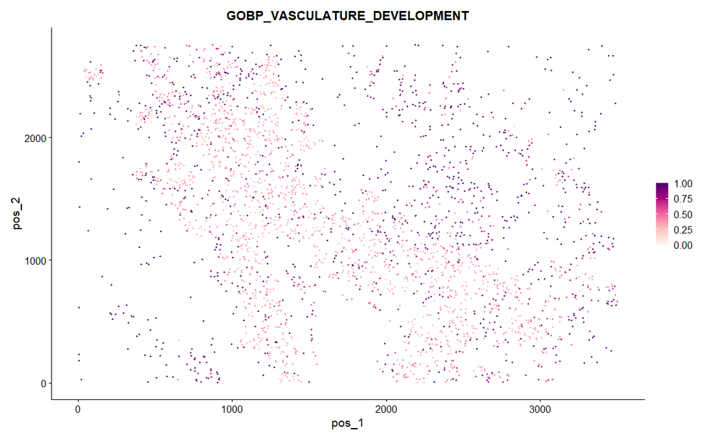

[output not shown]

[output cut: 109 more lines]

```r
seuBC1 <- AddMetaData(seuBC1, as.data.frame(enrich.score.BC1))

pathway <- "GOBP_VASCULATURE_DEVELOPMENT"
FeaturePlot(seuBC1, features = pathway, reduction = "pos") +
    scale_color_gradientn(
        colors = c("#fff7f3", "#fcc5c0", "#f768a1", "#ae017e", "#49006a"),
        values = scales::rescale(seq(0, 1, 0.25)),
        limits = c(0, 1)
    ) +
    theme(
        legend.position = "right",
        legend.justification = "center",
        legend.box = "vertical"
    )
```